### Deciding the quality of a work out.

This is the machine learning algorithm that I generated to determine if a workout was of high quality.

#### First we load the libraries.

```r
library(tibble)
library(tidyverse)
library(lubridate)
library(dplyr)
library(readr)
library(caret)
if(!file.exists("data")){
  dir.create("data")
}
```

#### Next we will load the data and store it under a directory ‘./data’

```r
fileUrl <- "https://d396qusza40orc.cloudfront.net/predmachlearn/pml-training.csv"
download.file(fileUrl,destfile="./data/pmltraining.csv",method="curl")
fileUrl2 <- "https://d396qusza40orc.cloudfront.net/predmachlearn/pml-testing.csv"
download.file(fileUrl2,destfile="./data/pmltesting.csv",method="curl")
list.files("./data")
```

```
## [1] "pmltesting.csv"  "pmltraining.csv"
```

```r
dateDownloaded <- date()
dateDownloaded
```

```
## [1] "Wed Mar 24 15:59:11 2021"
```

#### Next we will load the data into a dataframe.

```r
measurements <- (read_delim(file = "./data/pmltraining.csv", col_names = TRUE,
                      delim = ","))
```

#### Next the data needs to be cleaned.

In the initial data set there are 160 variables in each observation.

This reduced my observations from 160 to 38.

```r
measurements <- bind_cols(measurements[3:7],measurements[37:45], measurements[60:68], measurements[113:120], measurements[151:160])
measurements <- add_column(measurements, cvt_time = as_datetime(measurements$raw_timestamp_part_1 + measurements$raw_timestamp_part_2))
measurements <- bind_cols(measurements[6:42], measurements[5])
head(measurements)
```

```
## # A tibble: 6 x 38
##   gyros_belt_x gyros_belt_y gyros_belt_z accel_belt_x accel_belt_y accel_belt_z
##          <dbl>        <dbl>        <dbl>        <dbl>        <dbl>        <dbl>
## 1         0            0           -0.02          -21            4           22
## 2         0.02         0           -0.02          -22            4           22
## 3         0            0           -0.02          -20            5           23
## 4         0.02         0           -0.03          -22            3           21
## 5         0.02         0.02        -0.02          -21            2           24
## 6         0.02         0           -0.02          -21            4           21
## # … with 32 more variables: magnet_belt_x <dbl>, magnet_belt_y <dbl>,
## #   magnet_belt_z <dbl>, gyros_arm_x <dbl>, gyros_arm_y <dbl>,
## #   gyros_arm_z <dbl>, accel_arm_x <dbl>, accel_arm_y <dbl>, accel_arm_z <dbl>,
## #   magnet_arm_x <dbl>, magnet_arm_y <dbl>, magnet_arm_z <dbl>,
## #   gyros_dumbbell_x <dbl>, gyros_dumbbell_y <dbl>, gyros_dumbbell_z <dbl>,
## #   accel_dumbbell_x <dbl>, accel_dumbbell_y <dbl>, accel_dumbbell_z <dbl>,
## #   magnet_dumbbell_x <dbl>, magnet_dumbbell_y <dbl>, gyros_forearm_x <dbl>,
## #   gyros_forearm_y <dbl>, gyros_forearm_z <dbl>, accel_forearm_x <dbl>,
## #   accel_forearm_y <dbl>, accel_forearm_z <dbl>, magnet_forearm_x <dbl>,
## #   magnet_forearm_y <dbl>, magnet_forearm_z <dbl>, classe <chr>,
## #   cvt_time <dttm>, num_window <dbl>
```

#### Create Training and Test Sets

Next I created a training and a test set. The training set is about 60% of the data, and the test set is about 40% of the data.

```r
inTrain <- createDataPartition(y=measurements$classe,
                              p=.6, list=FALSE)
training <- measurements[inTrain,]
test <-   measurements[-inTrain,]
```

#### Exploratory Data Analysis.

Below are several plots that show there is some relationship between the accel_, gyros_, and magnet_ values and any one of the 4 areas where the sensors were worn. I will use this as the basis for my machine learning algorithm.

I also got concurance on this opinion from the paper that was referenced below:

Velloso, E.; Bulling, A.; Gellersen, H.; Ugulino, W.; Fuks, H. Qualitative Activity Recognition of Weight Lifting Exercises. Proceedings of 4th International Conference in Cooperation with SIGCHI (Augmented Human ’13) . Stuttgart, Germany: ACM SIGCHI, 2013.

Read more: Source

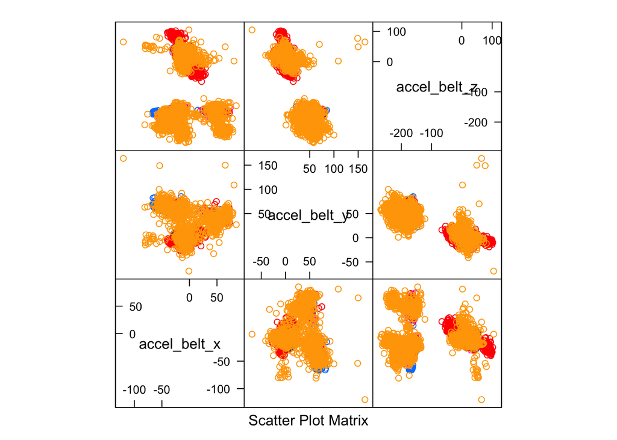

```r
featurePlot(x=training[,c("accel_belt_x", "accel_belt_y", "accel_belt_z")],
             y = factor(training$classe),
            plot="pairs", no.legend=F)
```

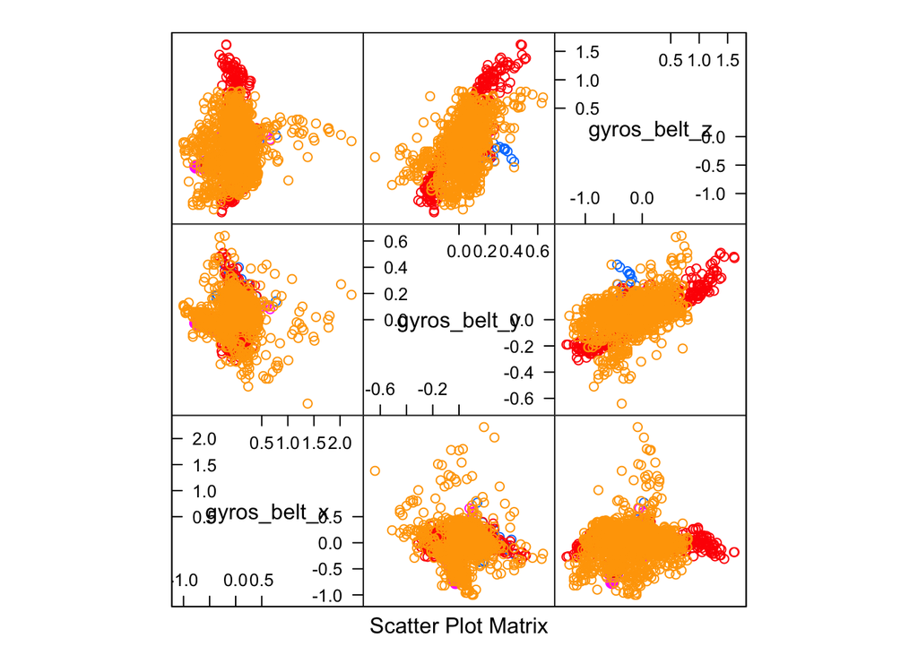

```r
featurePlot(x=training[,c("gyros_belt_x", "gyros_belt_y", "gyros_belt_z")],
            y = factor(training$classe),
            plot="pairs", no.legend=F)
```

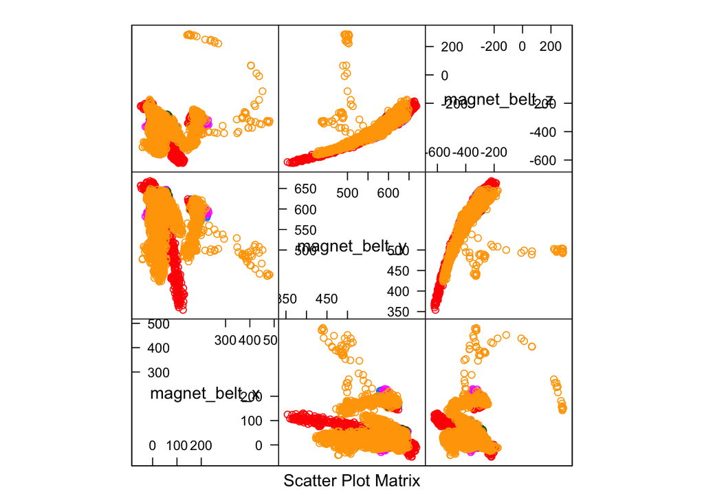

```r
featurePlot(x=training[,c("magnet_belt_x", "magnet_belt_y", "magnet_belt_z")],
            y = factor(training$classe),
            plot="pairs", no.legend=F)
```

#### Model Generation

Next I will train my model using the training data set. For this I used a random forest, initially I did try this with a boosting algorithm but I later found that the random forest algorithm provided a higher level of accuracy against the training set.

```r
modelFit <- train(classe ~. -num_window,data=training, method="rf",  allowParrallel = TRUE)

modelFit
```

```
## Random Forest
##
## 11776 samples
##    37 predictor
##     5 classes: 'A', 'B', 'C', 'D', 'E'
##
## No pre-processing
## Resampling: Bootstrapped (25 reps)
## Summary of sample sizes: 11776, 11776, 11776, 11776, 11776, 11776, ...
## Resampling results across tuning parameters:
##
##   mtry  Accuracy   Kappa
##    2    0.9712345  0.9636072
##   19    0.9651173  0.9558607
##   36    0.9513036  0.9383757
##
## Accuracy was used to select the optimal model using the largest value.
## The final value used for the model was mtry = 2.
```

#### Future Predictions

```r
pred <- predict(modelFit,test);

test$predRight <- pred==test$classe
table(pred,test$classe)
```

```
##
## pred    A    B    C    D    E
##    A 2214   25    0    7    0
##    B    0 1470   18    1    1
##    C    3   23 1349   39    5
##    D   15    0    1 1234    6
##    E    0    0    0    5 1430
```

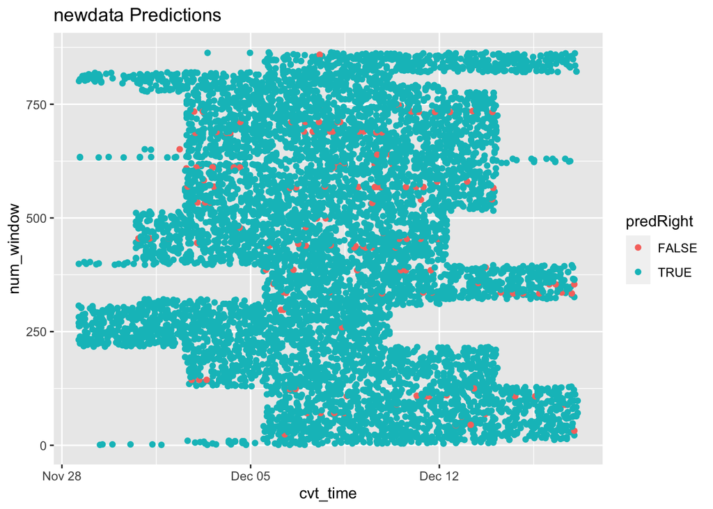

```r
qplot(cvt_time,num_window,colour=predRight,data=test,main="newdata Predictions")
```

#### Conclusion

As you can see from the above table, my algorithm was highly effective at identifying the classe of workout given the gyros_, accel_, and magnet_ observations for all for sources (dumbbell, forearm, arm, belt)